# Exercise 5: Nonparametric IRT in R

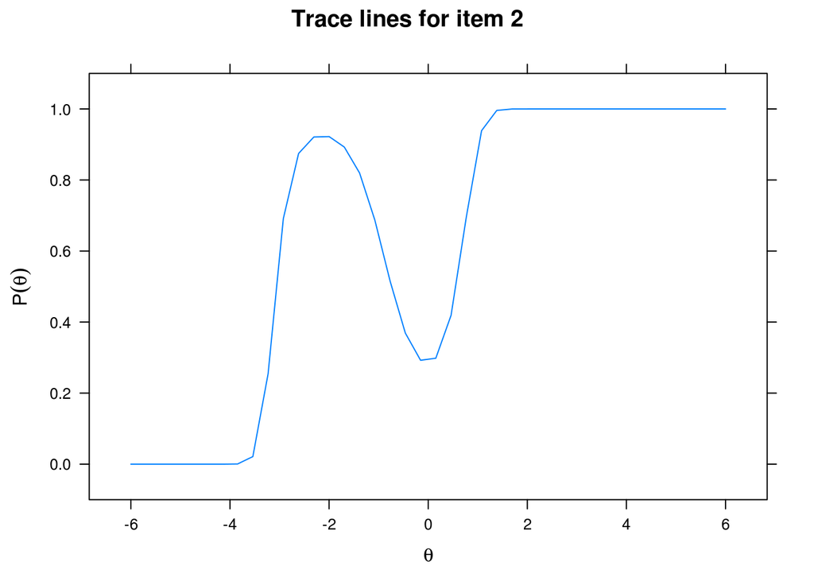

```r
itemplot(splinem,2) #odd, that looks like a spline gone wrong
```

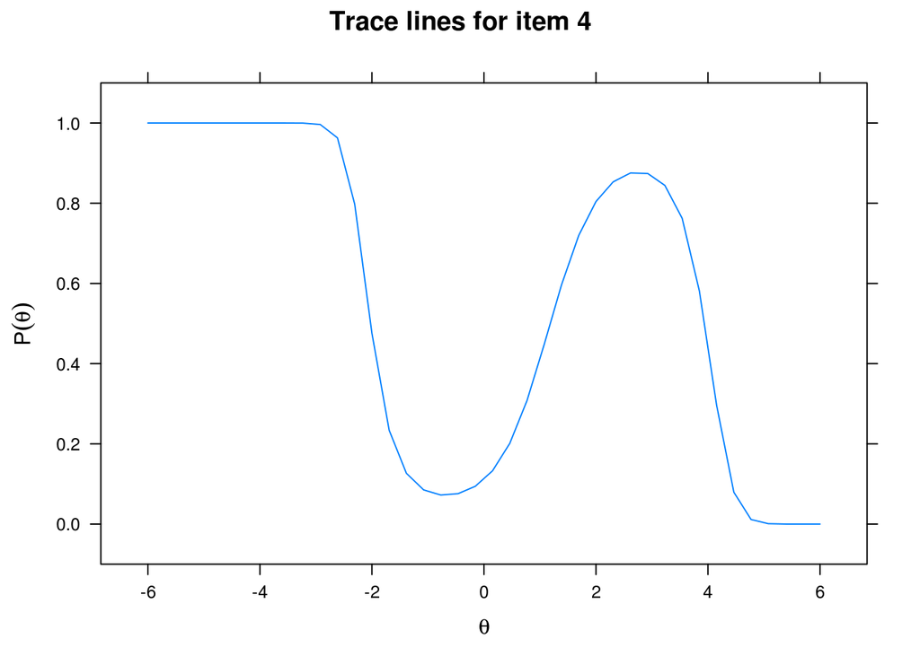

```r
itemplot(splinem,4) #odd, that looks like a spline gone wrong
```

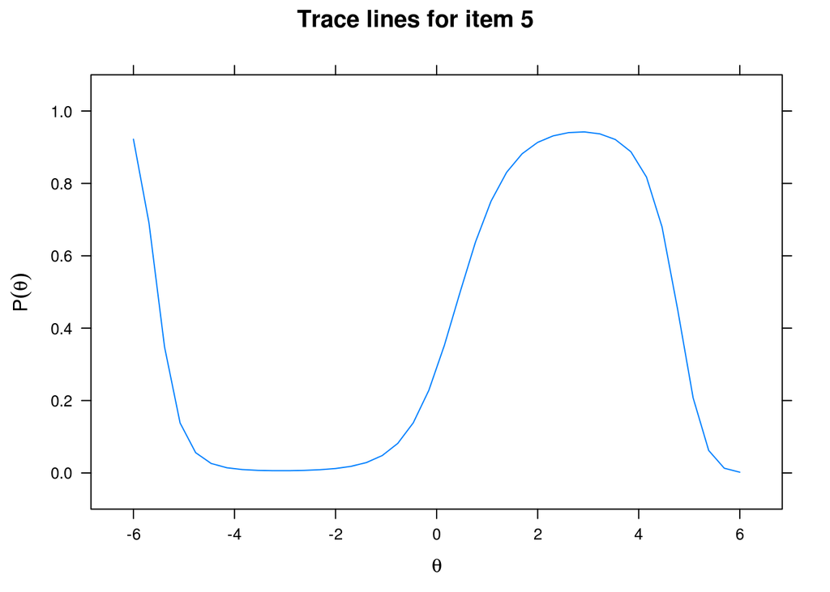

```r
itemplot(splinem,5) #odd, that looks like a spline gone wrong
```

6. The spline model gave us some indication of what happens but the fit is not yet satisfactory. There also seems to be something going on with the spline model for Items 2, 4, 5. It looks like the spline function is off (overfitting perhaps). We now use Kernel smoothing, which might bring the IRF out better. We fit a Kernel smoothing model with `ksIRT()`. Investigate the IRF with the plot method (`plottype=c("OCC","EIS")`). Check the latent score distribution with `plottype="density"`. Check the expected vs. the true observed score (`plottype="expected"`). Check the estimation standard error (`plottype="sd"`). What do you find with respect to Items 1 and 2, 4, 5?

```r
ksm <- ksIRT(responses=WIRS, key=rep(1,ncol(WIRS)),format=2)
ksm
```

```
##   Item Correlation
## 1    1      0.2851
## 2    2      0.3829
## 3    3      0.6386
## 4    4      0.5419
## 5    5      0.6769
## 6    6      0.5340
```

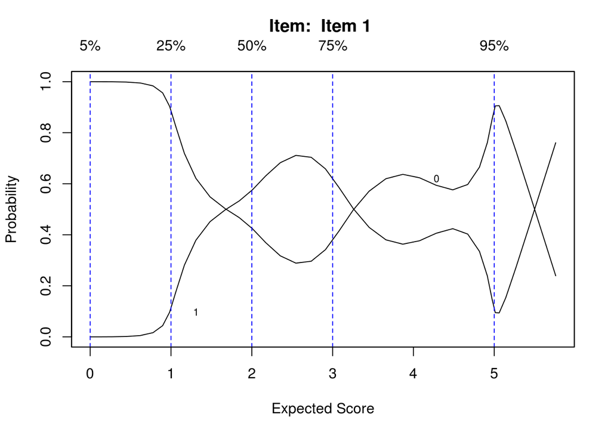

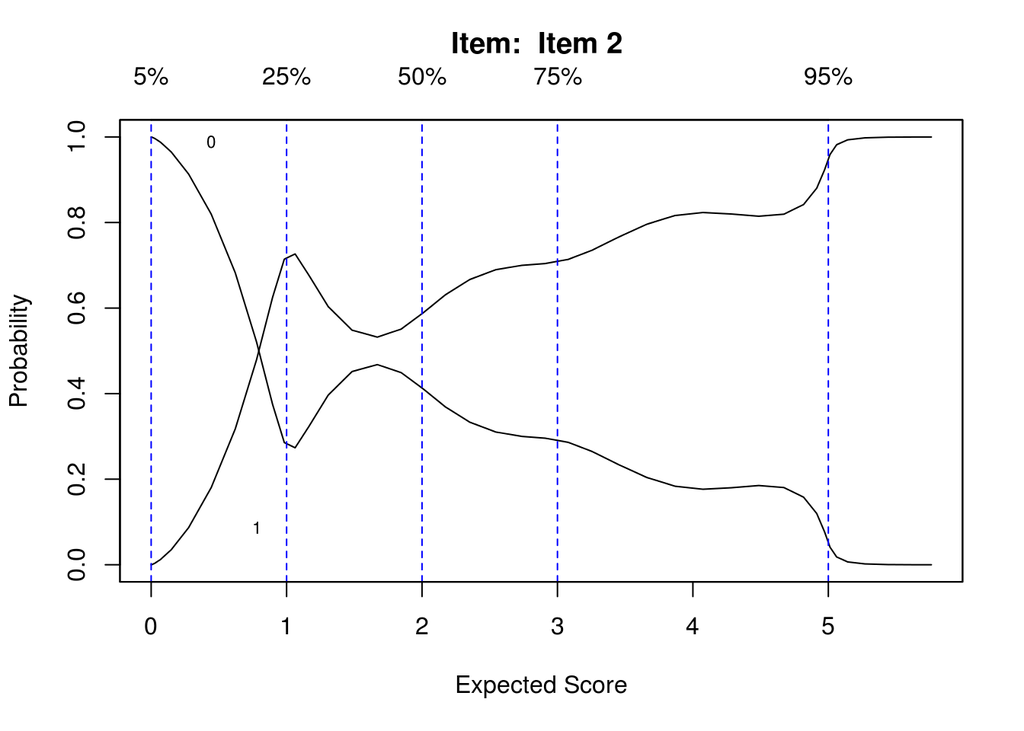

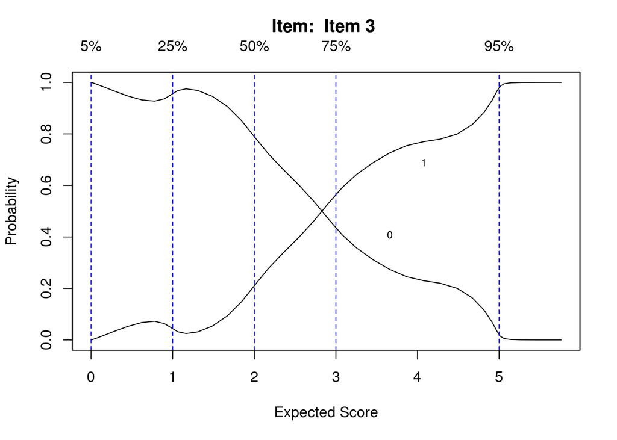

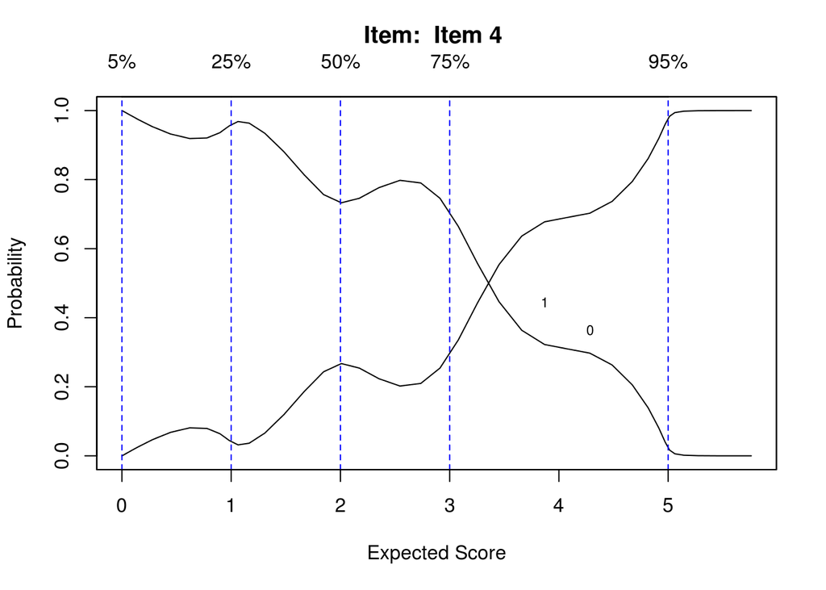

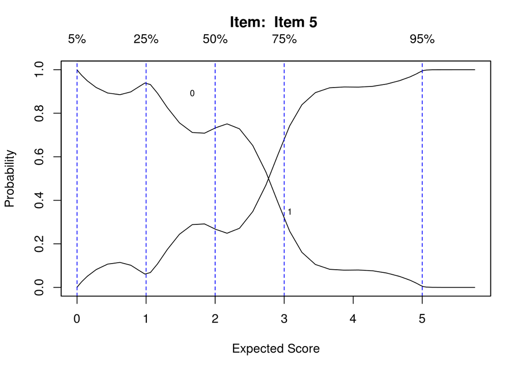

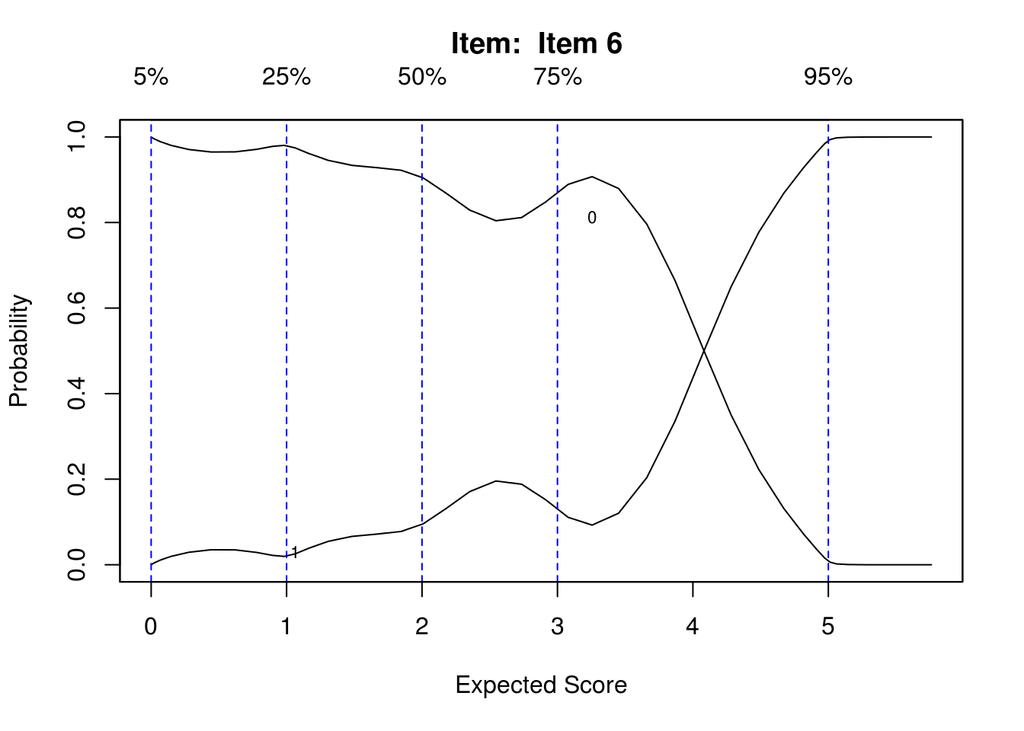

```r
plot(ksm,plottype="OCC")
```

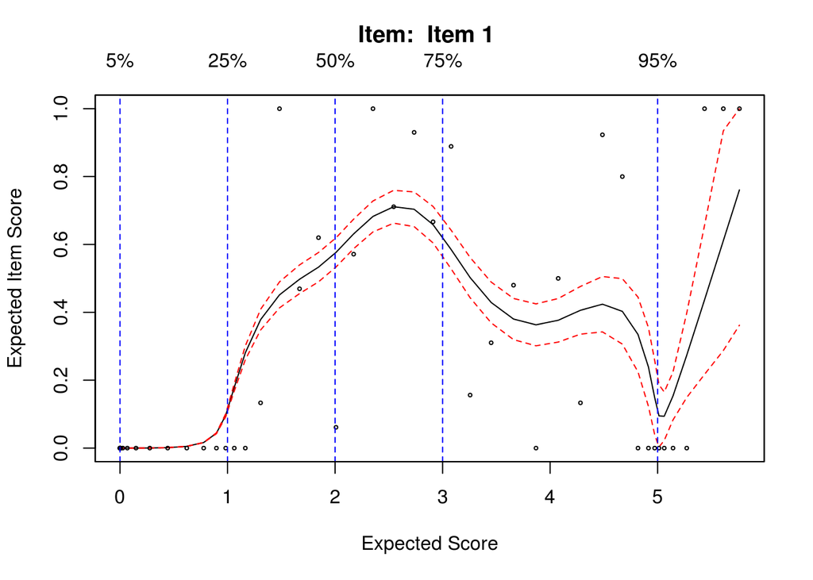

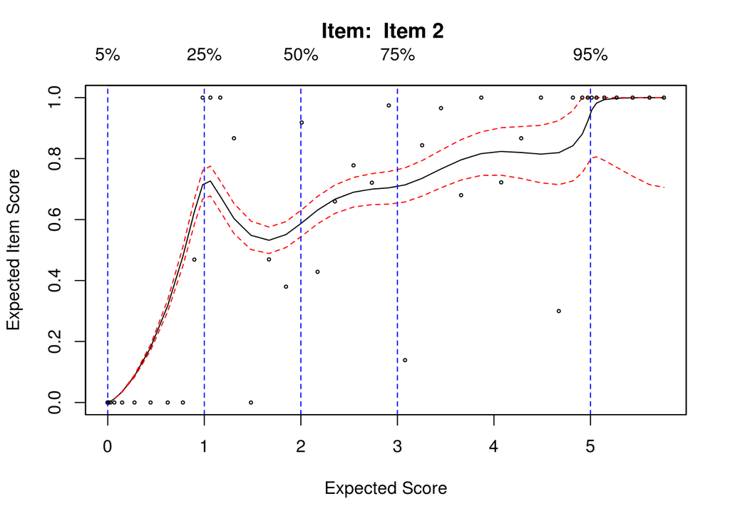

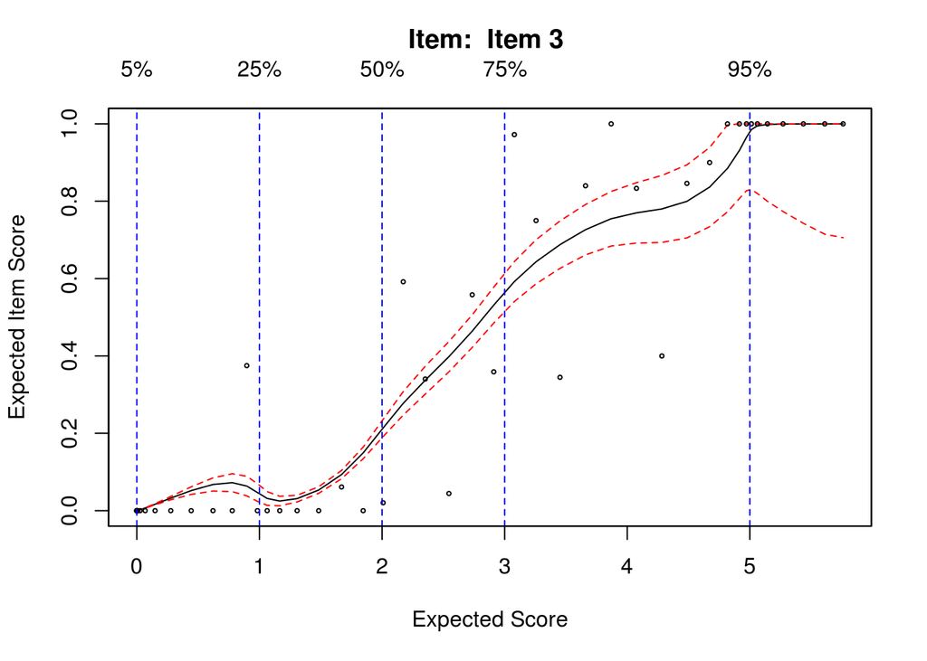

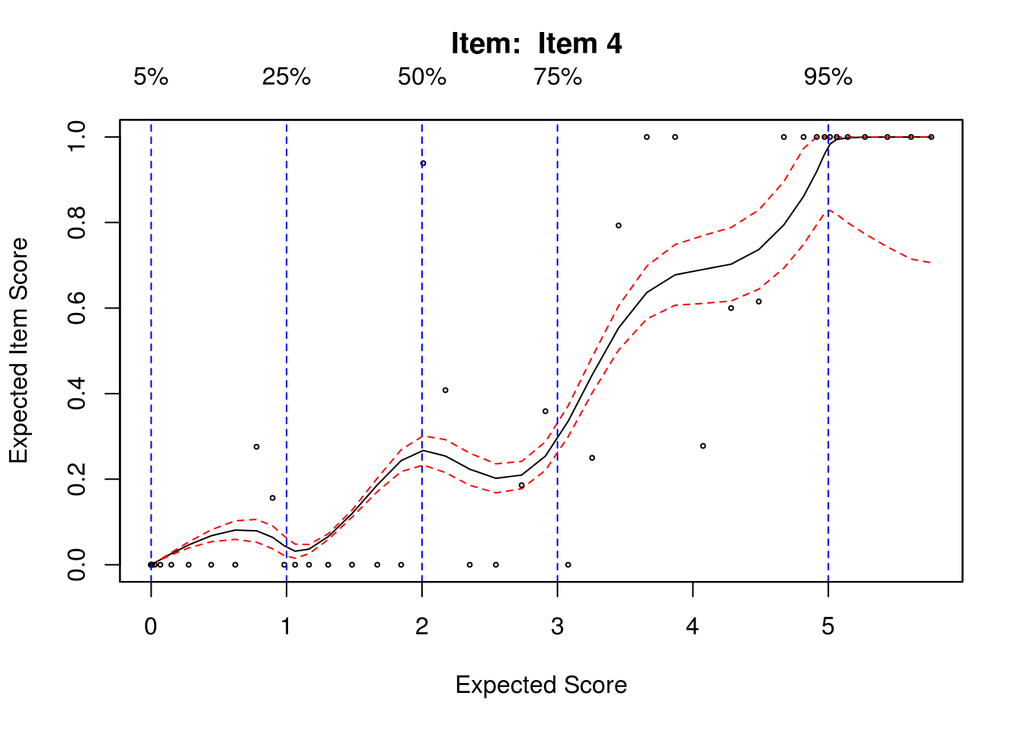

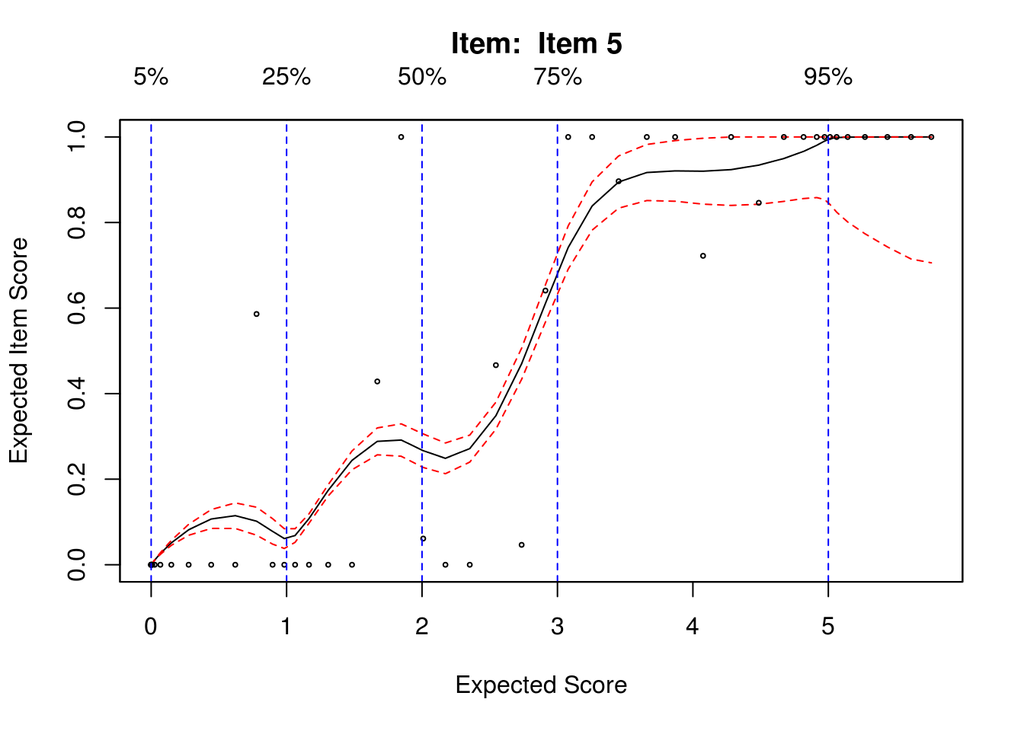

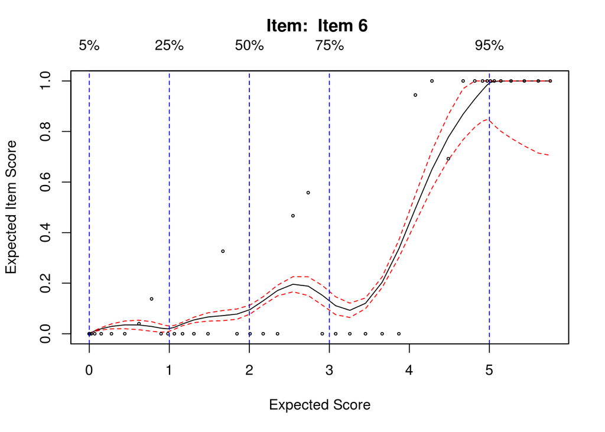

```r
plot(ksm,plottype="EIS")
```

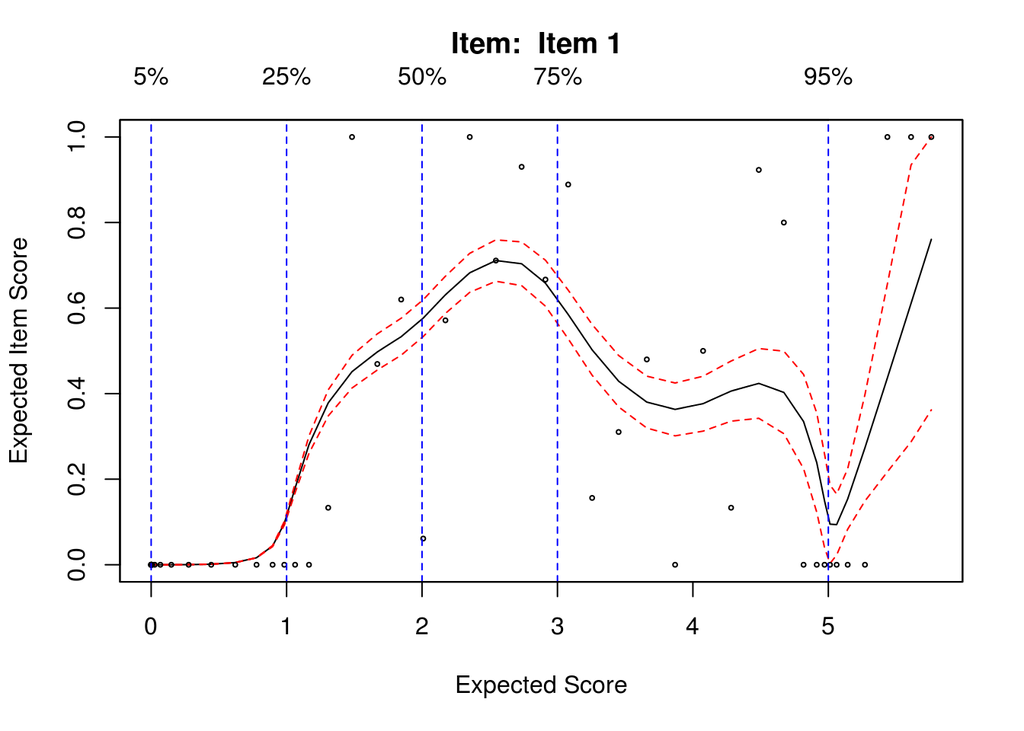

```r
plot(ksm,plottype="EIS",items=1) #non monotonic, ideal point style in the middle but not clear; item 1 is super odd
```

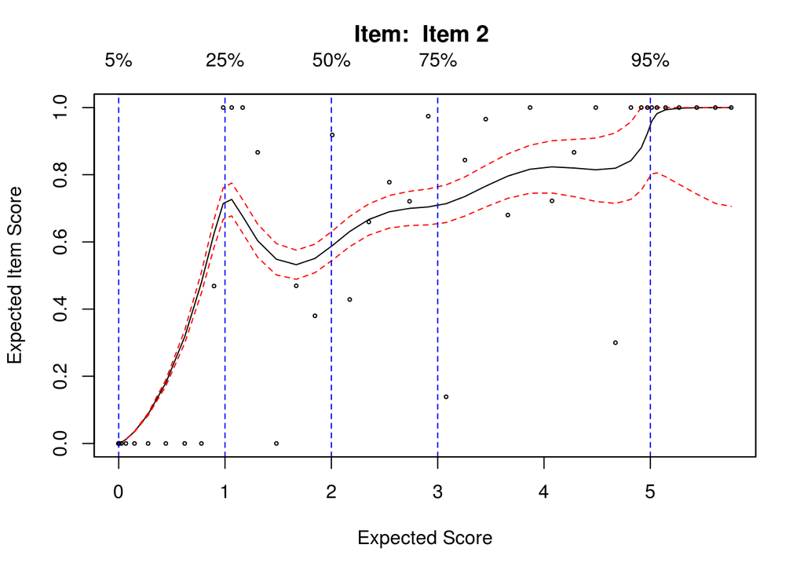

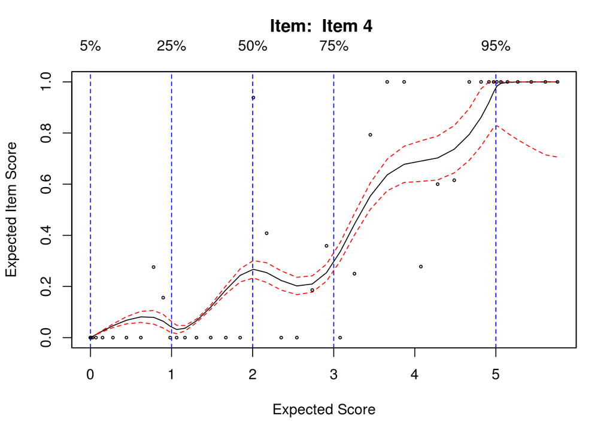

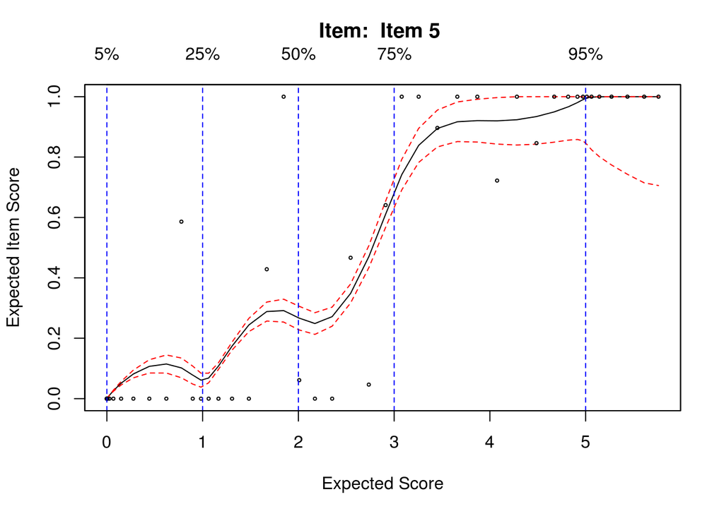

```r
plot(ksm,plottype="EIS",items=c(2,4,5)) #the IRF is less extreme than the spline, for 4 and 5 it seems ok. For item 2 there may be one indication for issues in the lower score range which the spline clearly overfits; also what mokken says
```